# Migration- Data Visualization Project

Jose Andres, Max, Richa Gupta, Sam

# The plight of migration

## Introduction

The most recent data in World Bank is available for the year 2017.

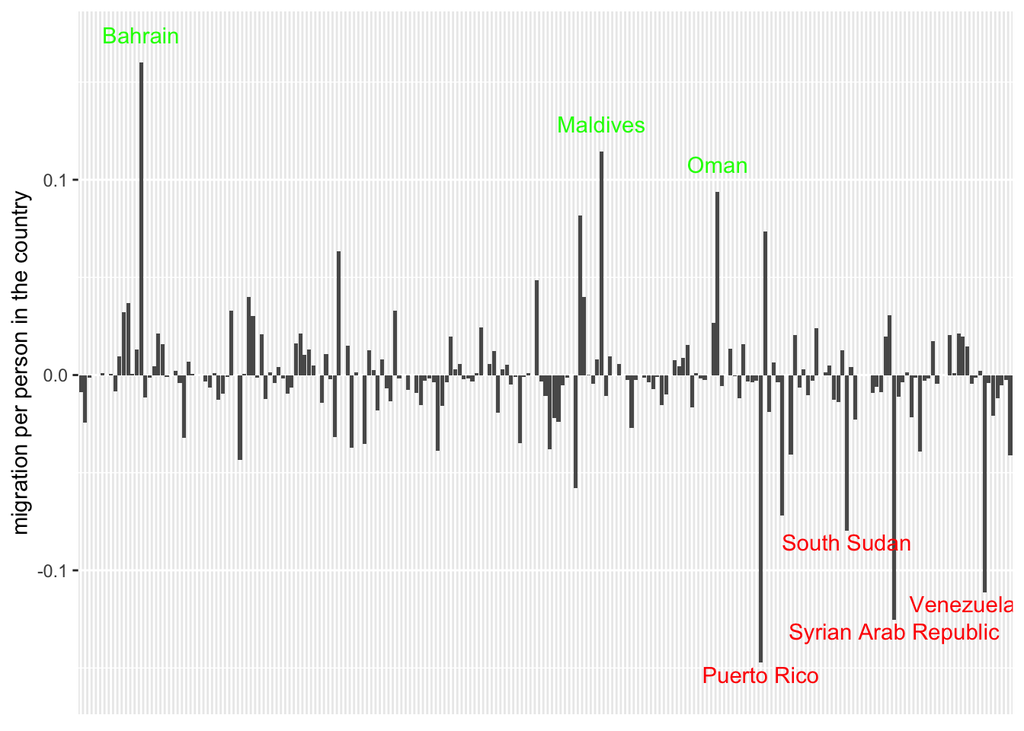

This graph shows that some countries stand out with higher than normal immigration like Bahrain, Maldives and Oman whereas some other countries are standing out because of all the people moving out of them. For example in Syria, for every 100 people in the country 12 people are moving to other countries.

We are interested in understanding what are the reasons that are making these people move out of their home countries.

We are removing Puerto Rico from our observations due to the fact that it is a part of United States and most of the migration that Puerto Rico faces is still inside of the country.

We are more interested in seeing the movement of people within countries and the reasons due to which this happens.

## Venezuela

Venezuela is a country located at the northern end of South America. It occupies a roughly triangular area that is larger than the combined areas of France and Germany.

The economy of Venezuela is a market-based mixed economy based largely on the petroleum and manufacturing sectors, and has been in a state of total economic collapse since the mid-2010s. This has aled to a mass-exodus of people from the country which has been facing an economic and political turmoil since a long time.

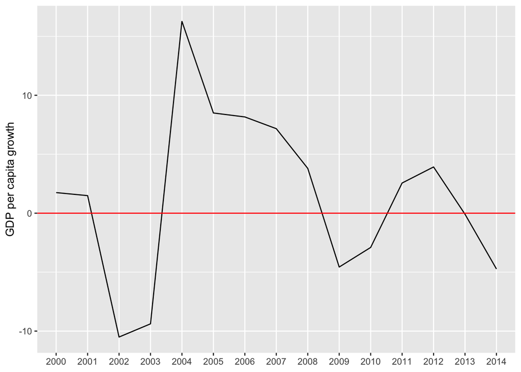

The GDP per capita growth has been dipping since reaching its peak in 2004.

Let us see what the migration trends of the country has been.

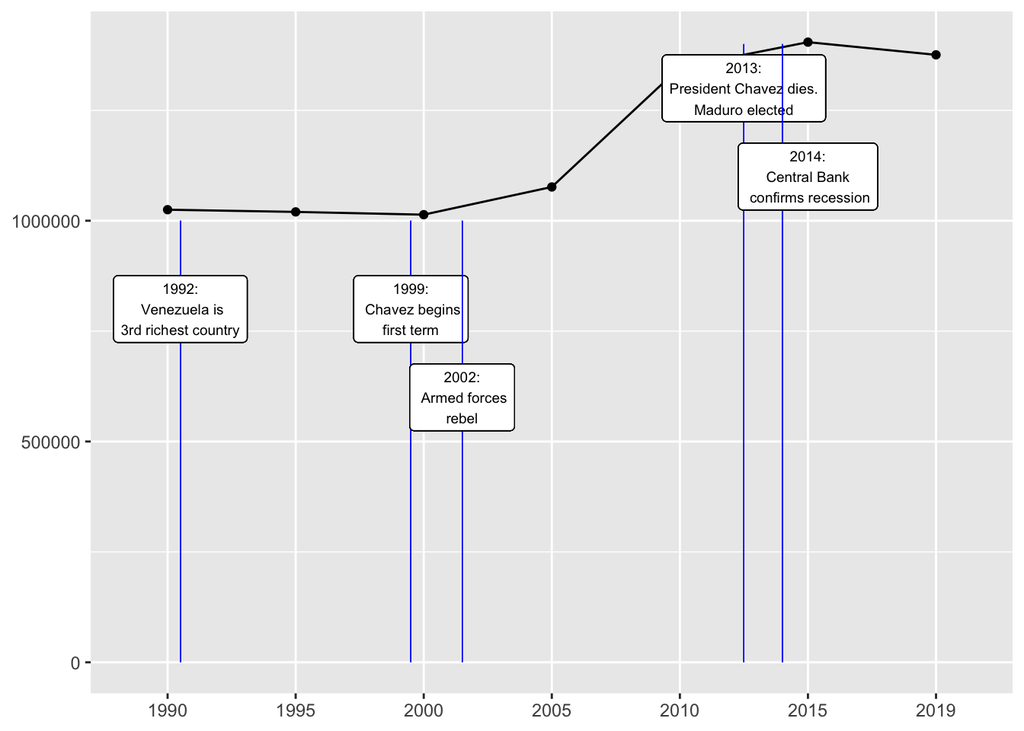

[interactive chart not shown]

## South Sudan

Made up of the 10 southern-most states of Sudan, South Sudan is one of the most diverse countries in Africa. It is home to over 60 different major ethnic groups, and the majority of its people follow traditional religions.

South Sudan gained independence from Sudan on 9 July 2011 as the outcome of a 2005 agreement that ended Africa’s longest-running civil war. Independence did not bring conflict in South Sudan to an end. Civil war broke out in 2013 when the president fell out with his then vice president, leading to a conflict that has displaced some 4 million people.

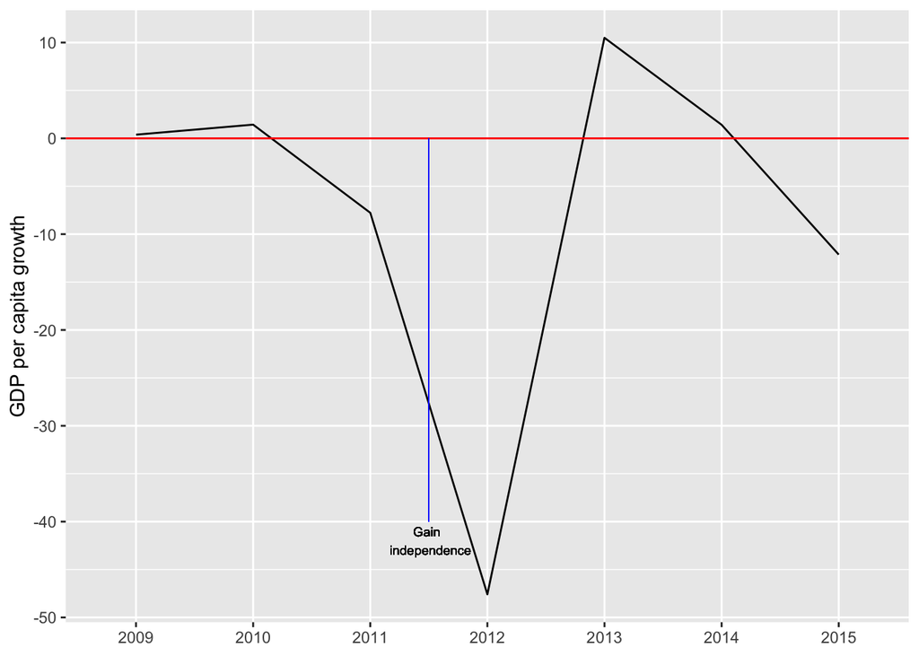

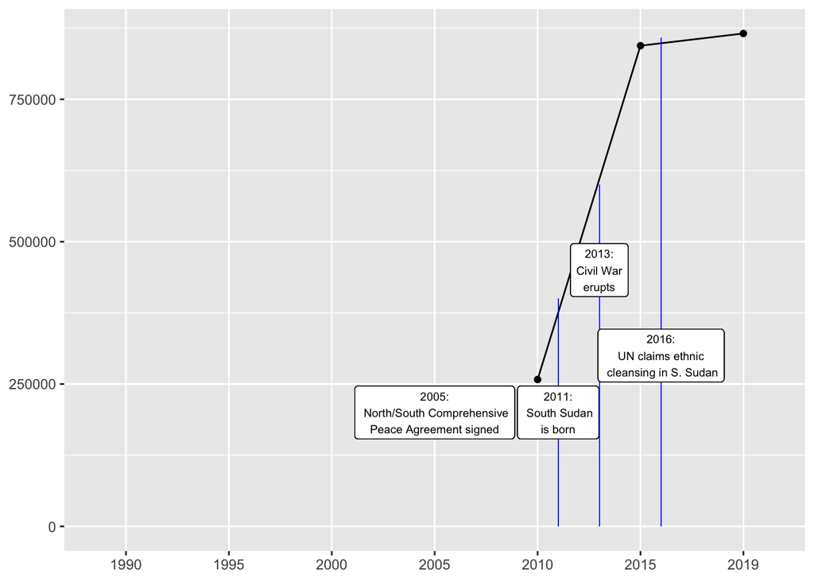

[interactive chart not shown]

## Syria

After Syria gained its independence in 1946, political life in the country was highly unstable, owing in large measure to intense friction between the country’s social, religious, and political groups. In 1970 Syria came under the authoritarian rule of Pres. Hafiz al-Assad. After Assad’s death in 2000, his son Bashar al-Assad became president. Bashar al-Assad ultimately continued his father’s authoritarian style of governments to quash political dissent. Long-suppressed internal tensions led to the outbreak of the Syrian Civil War in 2011.

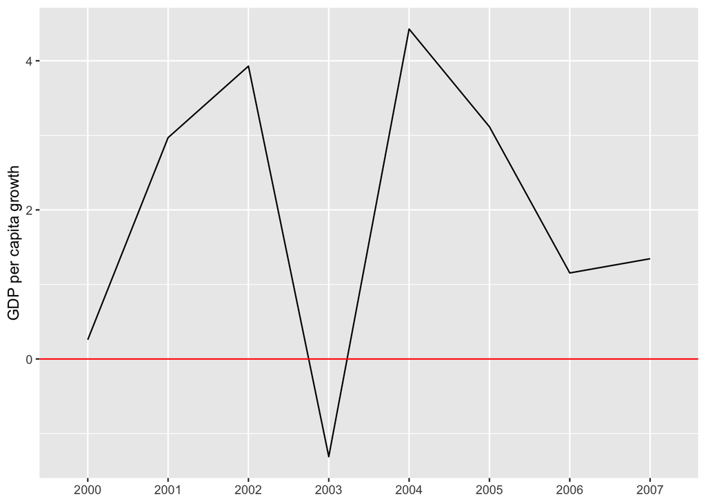

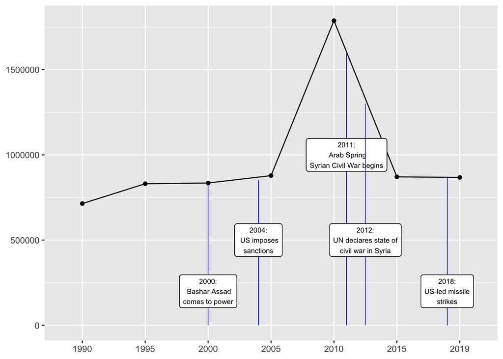

[interactive chart not shown]